# Understanding Function of Orthologous Genes

PI Ola Hansson, Lund University

Nikolay Oskolkov, SciLifeLab, NBIS Long Term Support, nikolay.oskolkov@scilifelab.se

May 18, 2018

Abstract

In this report we will use GTEX human gene expression data to build lists of tissue-specific genes and calculate their enrichment in the orthologous (and non-orthologous) gene sets.

### Loading and Exploring GTEX Data

We are going to use GTEX v.7 latest data set [1]. Let us have a look which tissues and how many samples are available in this GTEX release:

```r
library("psichomics")
gtex_tissues<-getGtexTissues("GTEx_v7_Annotations_SampleAttributesDS.txt")
gtex_tissues
```

```
##  Adipose Tissue (886 samples)   Adrenal Gland (205 samples)
##              "Adipose Tissue"               "Adrenal Gland"
##          Bladder (11 samples)          Blood (2560 samples)
##                     "Bladder"                       "Blood"
##   Blood Vessel (1041 samples)     Bone Marrow (160 samples)
##                "Blood Vessel"                 "Bone Marrow"
##          Brain (2076 samples)          Breast (306 samples)
##                       "Brain"                      "Breast"
##     Cervix Uteri (11 samples)           Colon (539 samples)
##                "Cervix Uteri"                       "Colon"
##      Esophagus (1111 samples)    Fallopian Tube (7 samples)
##                   "Esophagus"              "Fallopian Tube"
##           Heart (727 samples)           Kidney (50 samples)
##                       "Heart"                      "Kidney"
##           Liver (188 samples)            Lung (607 samples)
##                       "Liver"                        "Lung"
##          Muscle (718 samples)           Nerve (498 samples)
##                      "Muscle"                       "Nerve"
##           Ovary (138 samples)        Pancreas (268 samples)
##                       "Ovary"                    "Pancreas"
##       Pituitary (192 samples)        Prostate (159 samples)
##                   "Pituitary"                    "Prostate"
##  Salivary Gland (104 samples)           Skin (1362 samples)
##              "Salivary Gland"                        "Skin"
## Small Intestine (143 samples)          Spleen (169 samples)
##             "Small Intestine"                      "Spleen"
##         Stomach (272 samples)          Testis (284 samples)
##                     "Stomach"                      "Testis"
##         Thyroid (564 samples)          Uterus (117 samples)
##                     "Thyroid"                      "Uterus"
##          Vagina (124 samples)
##                      "Vagina"
```

```r
length(gtex_tissues)
```

```
## [1] 31
```

```r
tissues <- as.character(gtex_tissues)
```

Thus we seem to have 31 tissues while GTEX web-page says there are 53 tissues available. This difference is due to the fact that e.g. “Brain”" tissue has multiple cell types RNA sequenced separately. Let us now load the unnormalized gene expression data together with meta and phenotypic information about the donors:

```r
gtex <- loadGtexData(clinical="GTEx_v7_Annotations_SubjectPhenotypesDS.txt",
                     sampleMetadata="GTEx_v7_Annotations_SampleAttributesDS.txt",
                     junctionQuant=NULL,
                     geneExpr="All_Tissue_Site_Details.combined.reads.gct",tissues)
```

```
##
Read 0.0% of 56202 rows
Read 17.8% of 56202 rows
Read 35.6% of 56202 rows
Read 53.4% of 56202 rows
Read 71.2% of 56202 rows
Read 89.0% of 56202 rows
Read 56202 rows and 11689 (of 11690) columns from 1.691 GB file in 00:00:32
```

```r
names(gtex$GTEx)
```

```
## [1] "Sample metadata" "Clinical data"   "Gene expression"
```

```r
dim(gtex$GTEx$`Sample metadata`)
```

```
## [1] 15597    62
```

```r
gtex$GTEx$`Sample metadata`[1:5,1:5]
```

```
##                          Autolysis Score BSS collection site
## GTEX-1117F-0003-SM-5DWSB            <NA>                  B1
## GTEX-1117F-0003-SM-6WBT7            <NA>                  B1
## GTEX-1117F-0226-SM-5GZZ7            None                  B1
## GTEX-1117F-0426-SM-5EGHI            None                  B1
## GTEX-1117F-0526-SM-5EGHJ            None                  B1
##                                                                      Pathology Notes
## GTEX-1117F-0003-SM-5DWSB
## GTEX-1117F-0003-SM-6WBT7
## GTEX-1117F-0226-SM-5GZZ7                2 pieces, ~15% vessel stroma, rep delineated
## GTEX-1117F-0426-SM-5EGHI   2 pieces, !5% fibrous connective tissue, delineated (rep)
## GTEX-1117F-0526-SM-5EGHJ 2 pieces, clean, Monckebeg medial sclerosis, rep delineated
##                          RIN Number Tissue Type (area of retrieval)
## GTEX-1117F-0003-SM-5DWSB         NA                           Blood
## GTEX-1117F-0003-SM-6WBT7         NA                           Blood
## GTEX-1117F-0226-SM-5GZZ7        6.8                  Adipose Tissue
## GTEX-1117F-0426-SM-5EGHI        7.1                          Muscle
## GTEX-1117F-0526-SM-5EGHJ        8.0                    Blood Vessel
```

```r
dim(gtex$GTEx$`Clinical data`)
```

```
## [1] 750   3
```

```r
gtex$GTEx$`Clinical data`[1:3,1:3]
```

```
##             Sex   Age    Death Circumstances
## GTEX-111CU Male 50-59        Ventilator Case
## GTEX-111FC Male 60-69 Violent and fast death
## GTEX-111VG Male 60-69     Intermediate death
```

```r
dim(gtex$GTEx$`Gene expression`)
```

```
## [1] 56201 11687
```

```r
gtex$GTEx$`Gene expression`[1:5,1:5]
```

```
##                   GTEX-111CU-1826-SM-5GZYN GTEX-111FC-0226-SM-5N9B8
## ENSG00000227232.4                      395                      826
## ENSG00000243485.2                        1                        1
## ENSG00000237613.2                        0                        1
## ENSG00000268020.2                        0                        0
## ENSG00000240361.1                        2                        2
##                   GTEX-111VG-2326-SM-5N9BK GTEX-111YS-2426-SM-5GZZQ
## ENSG00000227232.4                      364                      301
## ENSG00000243485.2                        0                        1
## ENSG00000237613.2                        1                        0
## ENSG00000268020.2                        0                        0
## ENSG00000240361.1                        0                        0
##                   GTEX-1122O-2026-SM-5NQ91
## ENSG00000227232.4                      419
## ENSG00000243485.2                        0
## ENSG00000237613.2                        0
## ENSG00000268020.2                        0
## ENSG00000240361.1                        1
```

### Build Tissue-Specific Gene Sets

Now we will load the meadian TPM gene expression values across all samples for each tissue and have a look:

```r
gene_median<-read.delim("GTEx_Analysis_2016-01-15_v7_RNASeQCv1.1.8_gene_median_tpm.gct",
                        check.names=FALSE,header=TRUE,sep="\t")
rownames(gene_median)<-paste0(matrix(unlist(strsplit(as.character(gene_median$gene_id),"\\.")),
                                     byrow=TRUE,ncol=2)[,1],"__",gene_median$Description)
#rownames(gene_median)<-paste0(matrix(unlist(strsplit(as.character(gene_median$gene_id),"\\.")),
#                                     byrow=TRUE,ncol=2)[,1])
gene_median$gene_id<-NULL
gene_median$Description<-NULL
gene_median[1:5,1:5]
```

```
##                             Adipose - Subcutaneous
## ENSG00000223972__DDX11L1                  0.056945
## ENSG00000227232__WASH7P                  11.850000
## ENSG00000243485__MIR1302-11               0.061460
## ENSG00000237613__FAM138A                  0.038600
## ENSG00000268020__OR4G4P                   0.035695
##                             Adipose - Visceral (Omentum) Adrenal Gland
## ENSG00000223972__DDX11L1                         0.05054       0.07460
## ENSG00000227232__WASH7P                          9.75300       8.02300
## ENSG00000243485__MIR1302-11                      0.05959       0.08179
## ENSG00000237613__FAM138A                         0.03245       0.04050
## ENSG00000268020__OR4G4P                          0.00000       0.03479
##                             Artery - Aorta Artery - Coronary
## ENSG00000223972__DDX11L1           0.03976           0.04386
## ENSG00000227232__WASH7P           12.51000          12.30000
## ENSG00000243485__MIR1302-11        0.04297           0.05848
## ENSG00000237613__FAM138A           0.02815           0.03678
## ENSG00000268020__OR4G4P            0.00000           0.00000
```

Before we proceed with building tissue-specific gene sets lets us first exclude genes which do not overlap between two annotations: 1) annotation used by GTEX, 2) annotation used for processing orthologous sequences (hg38).

```r
full_annot<-scan("/home/nikolay/WABI/O_Hansson/FULL_ANNOT.txt",what="character")
genes_to_exclude<-setdiff(rownames(gene_median),intersect(full_annot,rownames(gene_median)))
gene_median<-gene_median[!rownames(gene_median)%in%genes_to_exclude,]
gene_median[1:5,1:5]
```

```
##                          Adipose - Subcutaneous
## ENSG00000223972__DDX11L1               0.056945
## ENSG00000227232__WASH7P               11.850000
## ENSG00000237613__FAM138A               0.038600
## ENSG00000268020__OR4G4P                0.035695
## ENSG00000240361__OR4G11P               0.042680
##                          Adipose - Visceral (Omentum) Adrenal Gland
## ENSG00000223972__DDX11L1                      0.05054      0.074600
## ENSG00000227232__WASH7P                       9.75300      8.023000
## ENSG00000237613__FAM138A                      0.03245      0.040500
## ENSG00000268020__OR4G4P                       0.00000      0.034790
## ENSG00000240361__OR4G11P                      0.03988      0.049065
##                          Artery - Aorta Artery - Coronary
## ENSG00000223972__DDX11L1        0.03976           0.04386
## ENSG00000227232__WASH7P        12.51000          12.30000
## ENSG00000237613__FAM138A        0.02815           0.03678
## ENSG00000268020__OR4G4P         0.00000           0.00000
## ENSG00000240361__OR4G11P        0.03399           0.00000
```

This information can be used for ranking tissues of predominant expression for each gene. For example for IDI2 (which we know is Skeletal Muscle specific gene) we can rank all tissues like this:

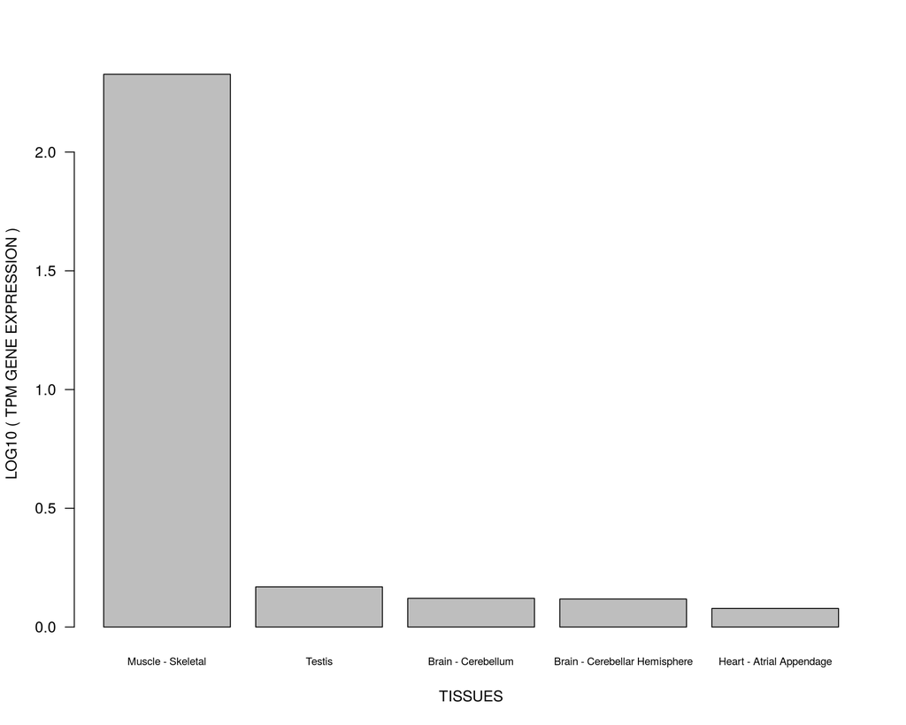

```r
IDI2_values<-log10(as.numeric(sort(gene_median["ENSG00000148377__IDI2",],decreasing=TRUE))+1)[1:5]
IDI2_names<-names(sort(gene_median["ENSG00000148377__IDI2",],decreasing=TRUE))[1:5]
#IDI2_values<-log10(as.numeric(sort(gene_median["ENSG00000148377",],decreasing=TRUE))+1)[1:5]
#IDI2_names<-names(sort(gene_median["ENSG00000148377",],decreasing=TRUE))[1:5]
barplot(IDI2_values,names.arg=IDI2_names,las=1,cex.names=0.7,ylab="LOG10 ( TPM GENE EXPRESSION )",xlab="TISSUES")
```

Now for each gene we are going to define the primary tissue of expression and demand that for the second ranked tissue the gene is one order of magnitude (10 times) less expressed than for the primary tissue we will call the gene “tissue specific gene” for that primary tissue:

```r
tissue<-vector()
tissue_specific_gene<-vector()
tissue_spec_coeff<-vector()
a<-seq(from=0,to=length(rownames(gene_median)),by=10000)
for(i in 1:length(rownames(gene_median)))
{
  if(isTRUE(i%in%a)==TRUE){print(paste("FINISHED ",i," FEATURES",sep=""))}
  gene_expr<-sort(gene_median[i,],decreasing=TRUE)
  if(as.numeric(rowSums(gene_expr))==0){next}

  if(as.numeric(gene_expr[1])!=0 & as.numeric(gene_expr[2])==0)
  {
    tissue<-append(tissue,names(gene_expr)[1])
    tissue_specific_gene<-append(tissue_specific_gene,rownames(gene_median[i,]))
    tissue_spec_coeff<-append(tissue_spec_coeff,Inf)
  }

  if(as.numeric(gene_expr[2])!=0 & as.numeric(gene_expr[1])/as.numeric(gene_expr[2])>=10)
  {
    tissue<-append(tissue,names(gene_expr)[1])
    tissue_specific_gene<-append(tissue_specific_gene,rownames(gene_median[i,]))
    tissue_spec_coeff<-append(tissue_spec_coeff,as.numeric(gene_expr[1])/as.numeric(gene_expr[2]))
  }
}
```

```
## [1] "FINISHED 10000 FEATURES"
## [1] "FINISHED 20000 FEATURES"
## [1] "FINISHED 30000 FEATURES"
## [1] "FINISHED 40000 FEATURES"
## [1] "FINISHED 50000 FEATURES"
```

```r
output_tissue_specific_genes<-data.frame(TISSUE=tissue,GENE=tissue_specific_gene,COEFF=tissue_spec_coeff,
                                         check.names=FALSE)
output_tissue_specific_genes<-output_tissue_specific_genes[order(-output_tissue_specific_genes$COEFF),]
head(output_tissue_specific_genes,20)
```

```
##                                 TISSUE                           GENE
## 4                               Testis  ENSG00000233234__RP11-740P5.2
## 5                               Testis  ENSG00000231630__RP11-740P5.3
## 9                               Testis   ENSG00000227169__RP1-37J18.1
## 10                              Testis   ENSG00000232596__RP1-37J18.2
## 11                              Testis ENSG00000231510__RP11-542C10.1
## 12                              Testis          ENSG00000173673__HES3
## 15                              Testis  ENSG00000237728__RP3-453P22.2
## 16                         Whole Blood  ENSG00000270330__RP5-892F13.2
## 21                              Testis  ENSG00000177553__RP11-56N19.5
## 25 Cells - EBV-transformed lymphocytes  ENSG00000227875__RP11-426M1.2
## 30                              Testis  ENSG00000231103__RP5-845O24.3
## 32                              Testis  ENSG00000234064__RP11-450I1.2
## 33                              Testis      ENSG00000204481__PRAMEF14
## 34                              Testis      ENSG00000253085__SCARNA11
```

[output cut: 27 more lines]

```r
length(unique(as.character(output_tissue_specific_genes$TISSUE)))
```

```
## [1] 51
```

Now all the genes are ranked by the coefficient of specificity, i.e. the fold change in gene expression between first ranked (primary) tissue and second ranked tissues. Lots of “Inf” specificity coefficients mostly correspond to non-coding genes (non-coding RNAs etc.) where the genes has a tiny expression in only one tissue, and zero expression anywhere else. We still want to keep them in the analysis but possibly one can also exclude them. Note that now we have 51 unique tissues with at least one tissue-specific gene.

Now, let us check how the tissue-specific gene set looks like for e.g. Skeletal Muscles and write the tissue-specific gene sets for each tissue into files:

```r
output_tissue_specific_genes[grepl("Muscle",as.character(output_tissue_specific_genes$TISSUE)),]
```

```
##                 TISSUE                           GENE     COEFF
## 251  Muscle - Skeletal      ENSG00000231072__GAPDHP64       Inf
## 496  Muscle - Skeletal ENSG00000240524__RP5-1061H20.3       Inf
## 829  Muscle - Skeletal    ENSG00000185631__AC017079.3       Inf
## 1252 Muscle - Skeletal       ENSG00000228963__OR7E93P       Inf
## 1350 Muscle - Skeletal   ENSG00000244381__RP11-3K16.1       Inf
## 1472 Muscle - Skeletal  ENSG00000249547__RP11-453O5.1       Inf
## 1970 Muscle - Skeletal    ENSG00000222939__AC079467.1       Inf
## 2158 Muscle - Skeletal        ENSG00000118990__GLRXP3       Inf
## 2252 Muscle - Skeletal  ENSG00000219314__RP1-273P12.1       Inf
## 2375 Muscle - Skeletal       ENSG00000199080__MIR133B       Inf
## 2630 Muscle - Skeletal       ENSG00000227404__KRT8P20       Inf
## 3170 Muscle - Skeletal    ENSG00000253115__RP11-6I2.4       Inf
## 3252 Muscle - Skeletal ENSG00000253619__RP11-369K17.1       Inf
## 3353 Muscle - Skeletal       ENSG00000179443__OR13C6P       Inf
```

[output cut: 72 more lines]

```r
unique_tissues<-unique(as.character(output_tissue_specific_genes$TISSUE))
for(i in unique_tissues)
{
  write.table(output_tissue_specific_genes[as.character(output_tissue_specific_genes$TISSUE)==i,],
              file=paste0("TISSUE_SPECIFIC_GENES/",i,".txt"),
              col.names=TRUE,row.names=FALSE,quote=FALSE,sep="\t")
}
```

Note that initially we had 51419 genes, and 7232 out of them can be classified as tissue-specific. This implies that each of the 51 tissues has in average 142 tissue-specific genes.

### Compare with Orthologous Genes

Now let us load the list of genes with orthologous information and have a look:

```r
orthologs<-read.delim("/home/nikolay/WABI/O_Hansson/ORTHOLOGOUS_GENES_NICE.txt",header=TRUE,sep="\t")
orthologs<-orthologs[!as.character(orthologs)%in%genes_to_exclude,]
head(orthologs,20)
```

```
##                              GENE ORTHO_LENGTH_PER_GENE GENE_LENGTH
## 1     ENSG00000251849__AC010887.1                 13755          84
## 2          ENSG00000212404__Y_RNA                 11951          97
## 3     ENSG00000239036__AC010209.1                  8351          82
## 4     ENSG00000222333__AC093680.1                  7372          79
## 5      ENSG00000206871__RNU6-533P                  9447         106
## 6     ENSG00000264437__AC107018.1                  6535          79
## 7     ENSG00000215993__AC079603.1                  6944          85
## 8       ENSG00000201744__RNU6-34P                  8253         106
## 9       ENSG00000212553__SNORD116                  7142          92
## 10    ENSG00000252226__AL451051.1                  4891          72
## 11    ENSG00000264804__AC098848.1                  6184         102
## 12     ENSG00000212442__RNU6-243P                  6059         106
## 13    ENSG00000277417__AC026341.1                  4920          88
## 14    ENSG00000211534__AL121588.1                  4115          75
```

[output cut: 27 more lines]

```r
#orthologs$GENE<-matrix(unlist(strsplit(as.character(orthologs$GENE),"__")),byrow=TRUE,ncol=2)[,1]
dim(orthologs)
```

```
## [1] 30902     4
```

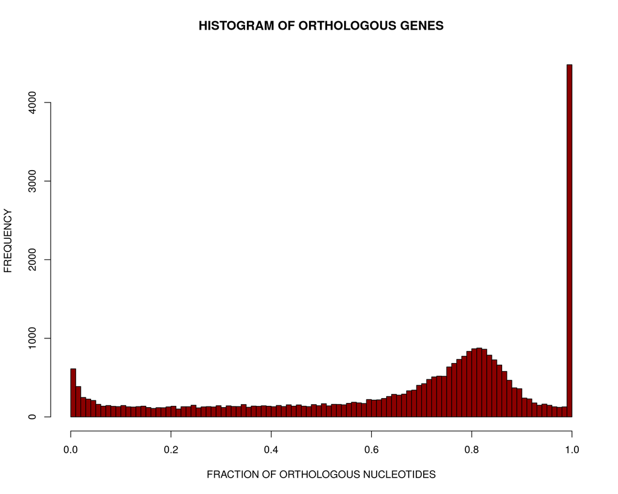

```r
hist(orthologs$FRACTION_ORTHO,breaks=100,xlab="FRACTION OF ORTHOLOGOUS NUCLEOTIDES",ylab="FREQUENCY",col="darkred",main="HISTOGRAM OF ORTHOLOGOUS GENES")
```

```r
library("VennDiagram")
```

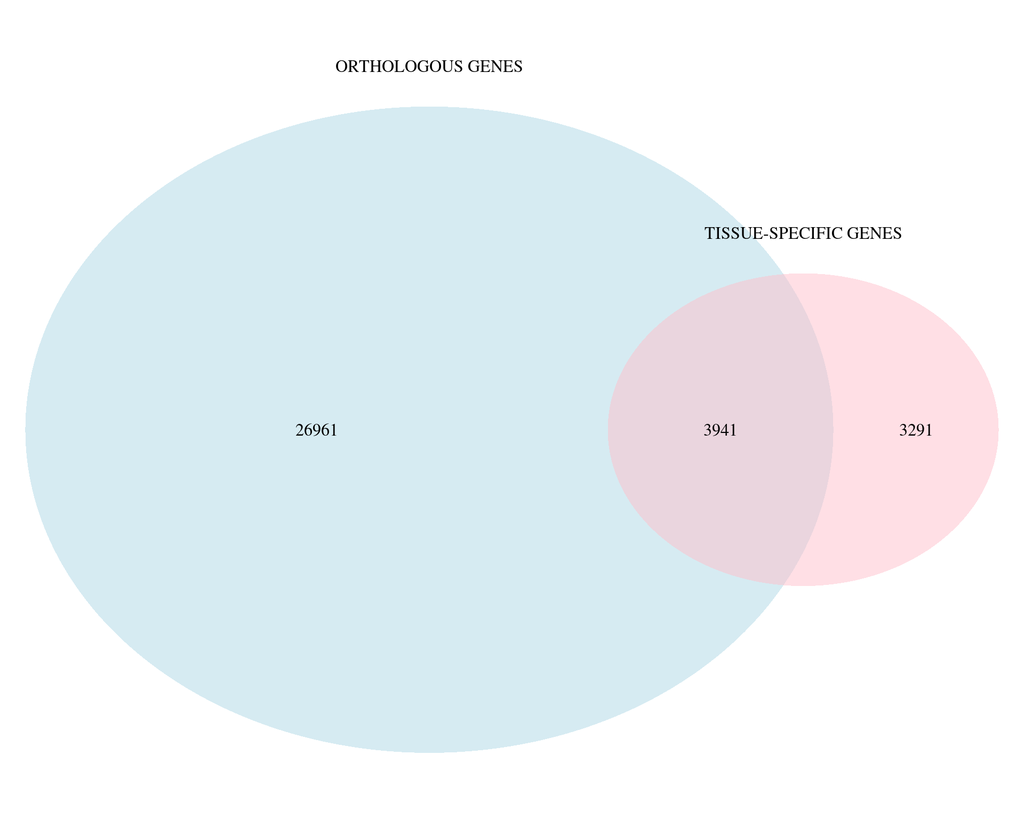

```
## (polygon[GRID.polygon.11], polygon[GRID.polygon.12], polygon[GRID.polygon.13], polygon[GRID.polygon.14], text[GRID.text.15], text[GRID.text.16], text[GRID.text.17], text[GRID.text.18], text[GRID.text.19])
```

```r
grid.newpage()
draw.pairwise.venn(dim(orthologs)[1], dim(output_tissue_specific_genes)[1], length(intersect(as.character(orthologs$GENE),as.character(output_tissue_specific_genes$GENE))), category = c("ORTHOLOGOUS GENES", "TISSUE-SPECIFIC GENES"), lty = rep("blank", 2), fill = c("light blue", "pink"), alpha = rep(0.5, 2), cat.pos = c(0, 0), cat.dist = rep(0.025, 2))
```

### Enrichment Analysis of Orthologous and Tissue-Specific Genes

Now let us build orthologous (similarity >= 60%) and non-orthologous (similarity <= 10%) gene lists and run enrichment analysis with resampling procedure:

```
## [1] "WORKING WITH FILE Adipose - Subcutaneous.txt"
## [1] "OBSERVED OVERLAP NON-ORTHOLOGOUS: 0"
## [1] "OBSERVED OVERLAP ORTHOLOGOUS: 1"
```

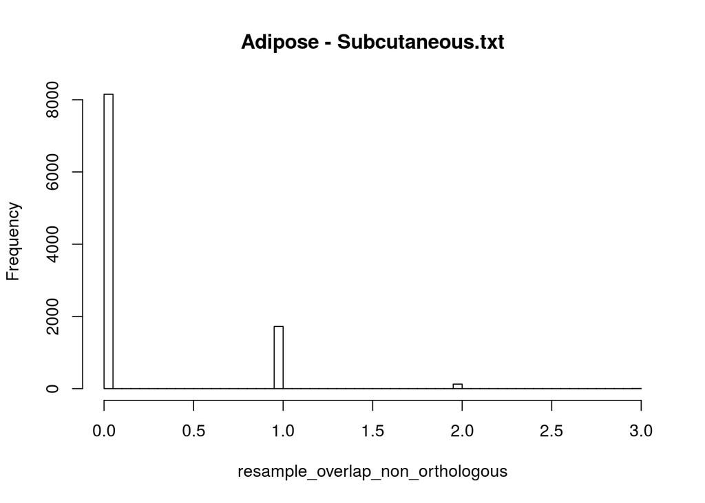

```
## [1] "MEAN OF RESAMPLED OVERLAP NON-ORTHOLOGOUS: 0.1975"
```

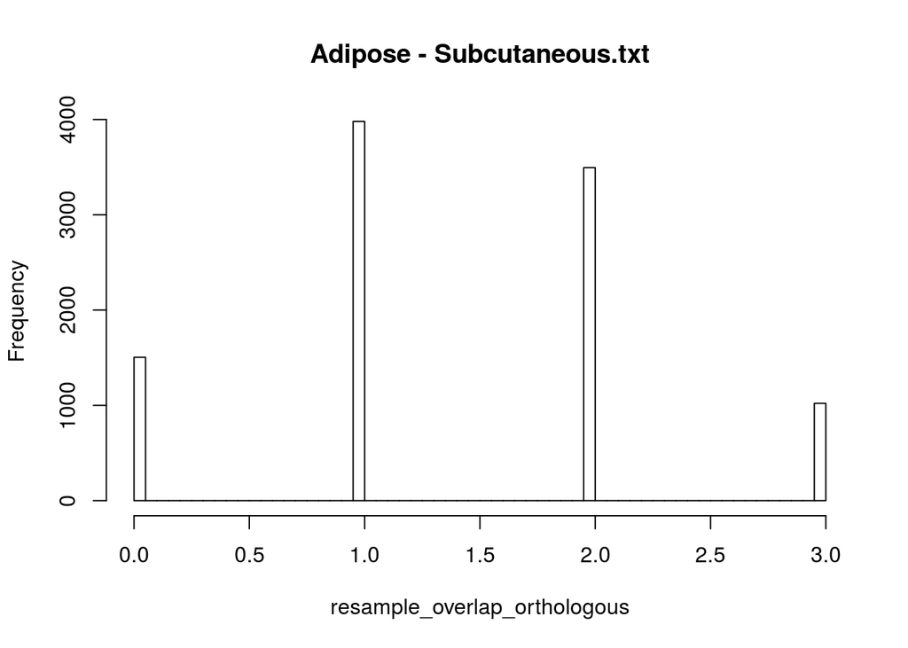

```
## [1] "MEAN OF RESAMPLED OVERLAP ORTHOLOGOUS: 1.4033"
## [1] "P-VALUE OF ENRICHMENT NON-ORTHOLOGOUS: 1"
## [1] "P-VALUE OF ENRICHMENT ORTHOLOGOUS: 0.8496"
## [1] "#################################################################################"
## [1] "WORKING WITH FILE Adrenal Gland.txt"
## [1] "OBSERVED OVERLAP NON-ORTHOLOGOUS: 1"
## [1] "OBSERVED OVERLAP ORTHOLOGOUS: 17"
```

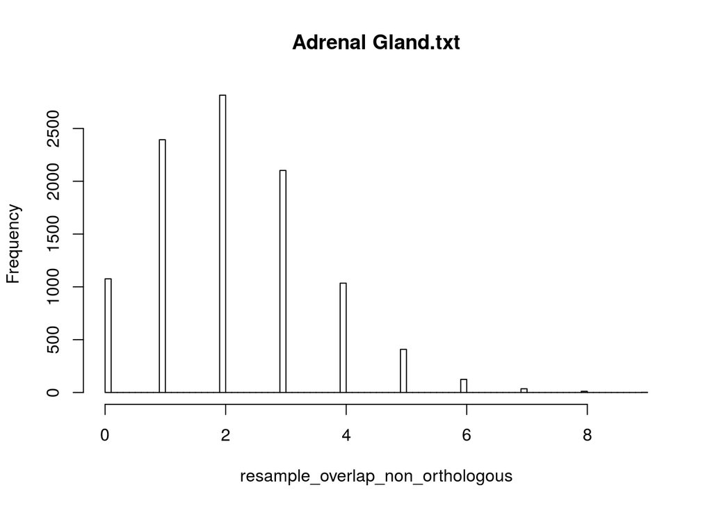

```
## [1] "MEAN OF RESAMPLED OVERLAP NON-ORTHOLOGOUS: 2.1595"
```

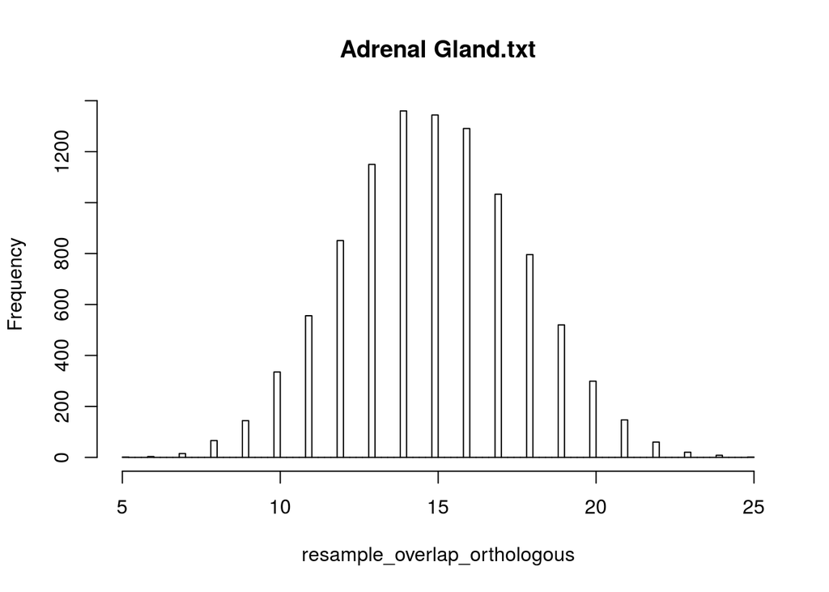

```
## [1] "MEAN OF RESAMPLED OVERLAP ORTHOLOGOUS: 14.9269"
## [1] "P-VALUE OF ENRICHMENT NON-ORTHOLOGOUS: 0.8924"
## [1] "P-VALUE OF ENRICHMENT ORTHOLOGOUS: 0.2884"
## [1] "#################################################################################"
## [1] "WORKING WITH FILE Artery - Aorta.txt"
## [1] "OBSERVED OVERLAP NON-ORTHOLOGOUS: 0"
## [1] "OBSERVED OVERLAP ORTHOLOGOUS: 5"
```

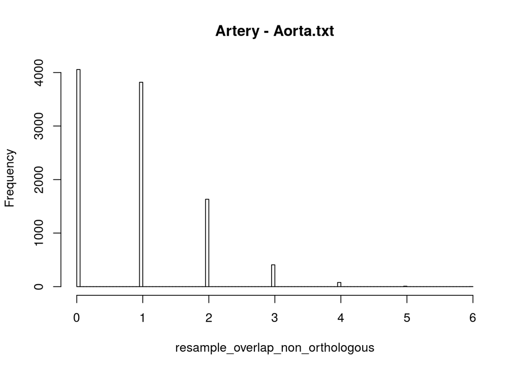

```
## [1] "MEAN OF RESAMPLED OVERLAP NON-ORTHOLOGOUS: 0.8661"
```

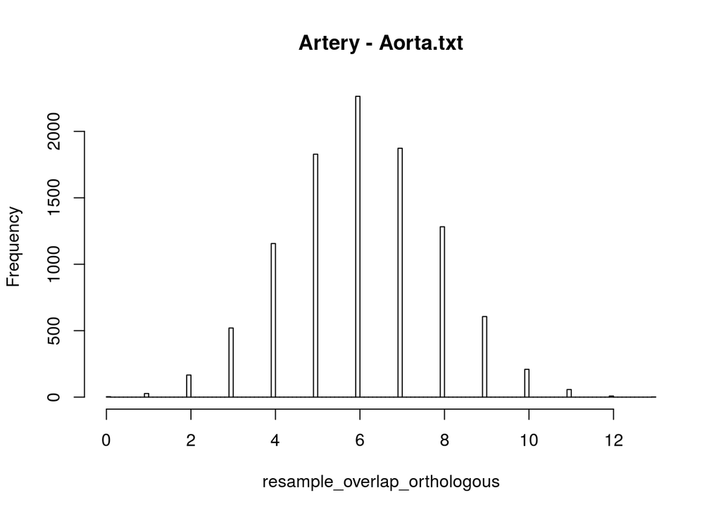

```
## [1] "MEAN OF RESAMPLED OVERLAP ORTHOLOGOUS: 6.0914"
## [1] "P-VALUE OF ENRICHMENT NON-ORTHOLOGOUS: 1"
## [1] "P-VALUE OF ENRICHMENT ORTHOLOGOUS: 0.8128"
## [1] "#################################################################################"
## [1] "WORKING WITH FILE Artery - Tibial.txt"
## [1] "OBSERVED OVERLAP NON-ORTHOLOGOUS: 0"
## [1] "OBSERVED OVERLAP ORTHOLOGOUS: 0"
```

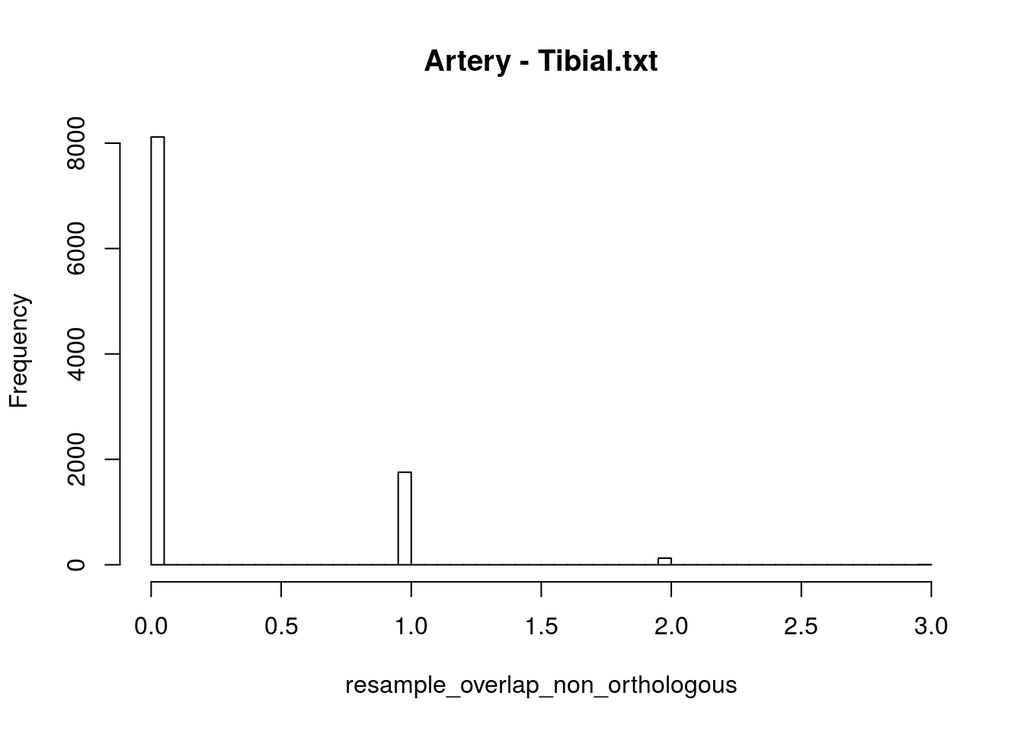

```
## [1] "MEAN OF RESAMPLED OVERLAP NON-ORTHOLOGOUS: 0.2014"
```

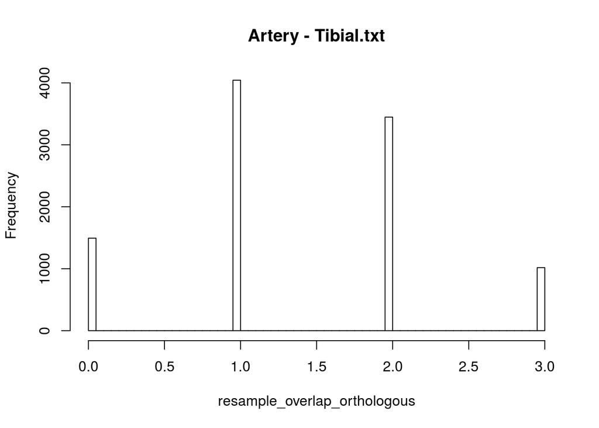

```
## [1] "MEAN OF RESAMPLED OVERLAP ORTHOLOGOUS: 1.3988"
## [1] "P-VALUE OF ENRICHMENT NON-ORTHOLOGOUS: 1"
## [1] "P-VALUE OF ENRICHMENT ORTHOLOGOUS: 1"
## [1] "#################################################################################"
## [1] "WORKING WITH FILE Bladder.txt"
## [1] "OBSERVED OVERLAP NON-ORTHOLOGOUS: 0"
## [1] "OBSERVED OVERLAP ORTHOLOGOUS: 12"
```

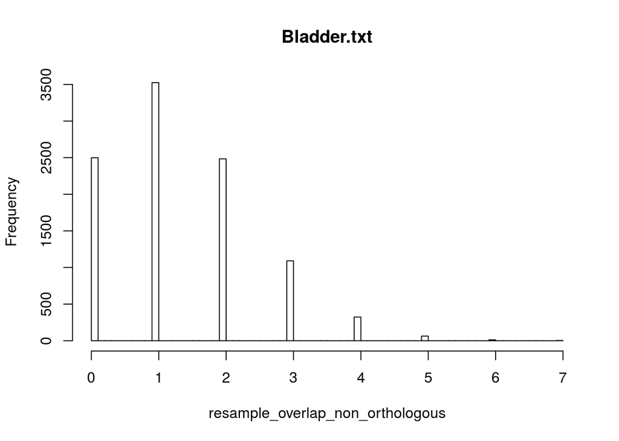

```
## [1] "MEAN OF RESAMPLED OVERLAP NON-ORTHOLOGOUS: 1.3466"
```

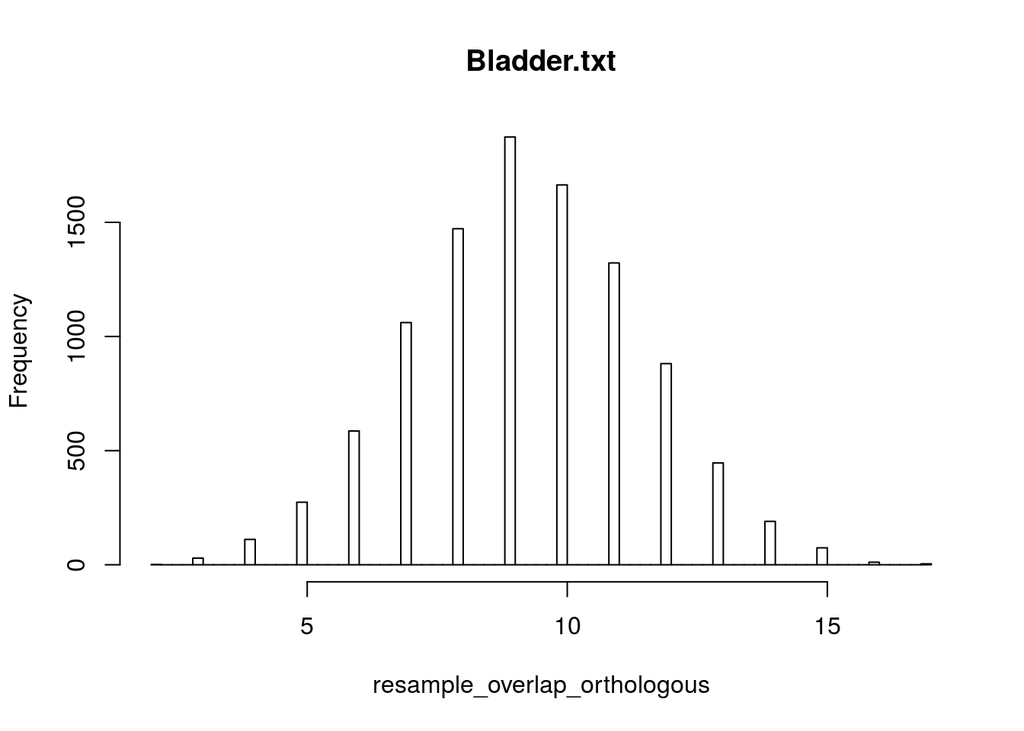

```
## [1] "MEAN OF RESAMPLED OVERLAP ORTHOLOGOUS: 9.3054"
## [1] "P-VALUE OF ENRICHMENT NON-ORTHOLOGOUS: 1"
## [1] "P-VALUE OF ENRICHMENT ORTHOLOGOUS: 0.1606"
## [1] "#################################################################################"
## [1] "WORKING WITH FILE Brain - Amygdala.txt"
## [1] "OBSERVED OVERLAP NON-ORTHOLOGOUS: 0"
## [1] "OBSERVED OVERLAP ORTHOLOGOUS: 1"
```

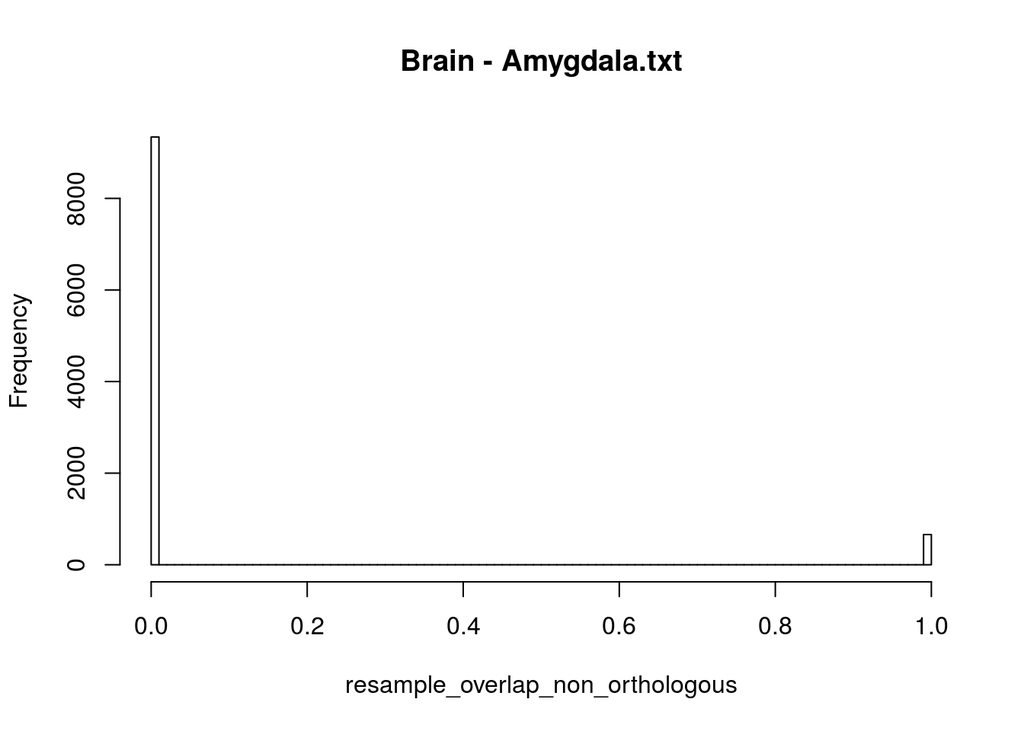

```
## [1] "MEAN OF RESAMPLED OVERLAP NON-ORTHOLOGOUS: 0.0659"
```

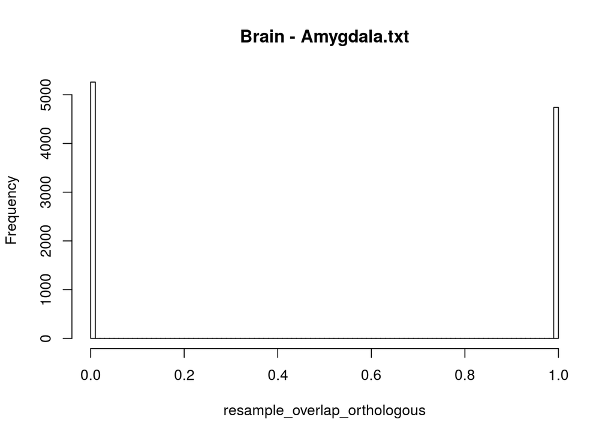

```
## [1] "MEAN OF RESAMPLED OVERLAP ORTHOLOGOUS: 0.474"
## [1] "P-VALUE OF ENRICHMENT NON-ORTHOLOGOUS: 1"
## [1] "P-VALUE OF ENRICHMENT ORTHOLOGOUS: 0.474"
## [1] "#################################################################################"
## [1] "WORKING WITH FILE Brain - Anterior cingulate cortex (BA24).txt"
## [1] "OBSERVED OVERLAP NON-ORTHOLOGOUS: 0"
## [1] "OBSERVED OVERLAP ORTHOLOGOUS: 1"
```

[90 more figures not shown]

```
## [1] "MEAN OF RESAMPLED OVERLAP ORTHOLOGOUS: 43.2644"
## [1] "P-VALUE OF ENRICHMENT NON-ORTHOLOGOUS: 0.9991"
## [1] "P-VALUE OF ENRICHMENT ORTHOLOGOUS: 1"
## [1] "#################################################################################"
```

```r
#BUILD OTHOLOGOUS AND NON_ORTHOLOGOUS GENES LISTS
non_orthologous_genes<-orthologs[orthologs$FRACTION_ORTHO<=0.1,]
orthologous_genes<-orthologs[orthologs$FRACTION_ORTHO>=0.6,]

#FIND OVERLAP BETWEEN ORTHOLOGOUS AND TISSUE SPECIFIC GENES
gene_pool<-union(as.character(orthologs$GENE),as.character(output_tissue_specific_genes$GENE))
my_tissues<-list.files("TISSUE_SPECIFIC_GENES/")
observed_overlap_non_orthologous_vector<-vector()
observed_overlap_orthologous_vector<-vector()
mean_resample_overlap_non_orthologous_vector<-vector()
mean_resample_overlap_orthologous_vector<-vector()
p_value_enrichment_non_orthologous<-vector()
p_value_enrichment_orthologous<-vector()
for(j in 1:length(my_tissues))
{
my_tissue<-read.delim(paste0("TISSUE_SPECIFIC_GENES/",my_tissues[j]),header=TRUE,sep="\t")
#muscle<-output_tissue_specific_genes[grepl("Muscle",as.character(output_tissue_specific_genes$TISSUE)),]
print(paste0("WORKING WITH FILE ",my_tissues[j]))
observed_overlap_non_orthologous<-length(intersect(as.character(my_tissue$GENE),
                                                   as.character(non_orthologous_genes$GENE)))
print(paste0("OBSERVED OVERLAP NON-ORTHOLOGOUS: ",observed_overlap_non_orthologous))
observed_overlap_non_orthologous_vector<-append(observed_overlap_non_orthologous_vector,
                                                observed_overlap_non_orthologous)

observed_overlap_orthologous<-length(intersect(as.character(my_tissue$GENE),
                                                   as.character(orthologous_genes$GENE)))
print(paste0("OBSERVED OVERLAP ORTHOLOGOUS: ",observed_overlap_orthologous))
observed_overlap_orthologous_vector<-append(observed_overlap_orthologous_vector,
                                                observed_overlap_orthologous)

resample_overlap_non_orthologous<-vector()
resample_overlap_orthologous<-vector()
N<-10000
for(i in 1:N)
{
  my_tissue_resample<-gene_pool[sample(1:length(gene_pool),dim(my_tissue)[1],replace=TRUE)]
  non_orthologous_resample<-gene_pool[sample(1:length(gene_pool),dim(non_orthologous_genes)[1],replace=TRUE)]
  orthologous_resample<-gene_pool[sample(1:length(gene_pool),dim(orthologous_genes)[1],replace=TRUE)]
  resample_overlap_non_orthologous<-append(resample_overlap_non_orthologous,
                                           length(intersect(my_tissue_resample,non_orthologous_resample)))
  resample_overlap_orthologous<-append(resample_overlap_orthologous,
                                           length(intersect(my_tissue_resample,orthologous_resample)))
}
hist(resample_overlap_non_orthologous,breaks=100,main=my_tissues[j])
print(paste0("MEAN OF RESAMPLED OVERLAP NON-ORTHOLOGOUS: ",mean(resample_overlap_non_orthologous)))
mean_resample_overlap_non_orthologous_vector<-append(mean_resample_overlap_non_orthologous_vector,
                                                     mean(resample_overlap_non_orthologous))
hist(resample_overlap_orthologous,breaks=100,main=my_tissues[j])
print(paste0("MEAN OF RESAMPLED OVERLAP ORTHOLOGOUS: ",mean(resample_overlap_orthologous)))
mean_resample_overlap_orthologous_vector<-append(mean_resample_overlap_orthologous_vector,
                                                     mean(resample_overlap_orthologous))
print(paste0("P-VALUE OF ENRICHMENT NON-ORTHOLOGOUS: ",
             sum(resample_overlap_non_orthologous>=observed_overlap_non_orthologous)/N))
p_value_enrichment_non_orthologous<-append(p_value_enrichment_non_orthologous,
                                           sum(resample_overlap_non_orthologous>=observed_overlap_non_orthologous)/N)
print(paste0("P-VALUE OF ENRICHMENT ORTHOLOGOUS: ",
             sum(resample_overlap_orthologous>=observed_overlap_orthologous)/N))
p_value_enrichment_orthologous<-append(p_value_enrichment_orthologous,
                                       sum(resample_overlap_orthologous>=observed_overlap_orthologous)/N)
print("#################################################################################")
}
```

```r
output_enrichment<-data.frame(TISSUE=matrix(unlist(strsplit(my_tissues,"\\.")),byrow=TRUE,ncol=2)[,1],
                              OBSERVED_NON_ORTHOLOGOUS=observed_overlap_non_orthologous_vector,
                              OBSERVED_ORTHOLOGOUS=observed_overlap_orthologous_vector,
                              MEAN_RESAMPLE_NON_ORTHOLOGOUS=mean_resample_overlap_non_orthologous_vector,
                              MEAN_RESAMPLE_ORTHOLOGOUS=mean_resample_overlap_orthologous_vector,
                              P_VALUE_ENRICHMENT_NON_ORTHOLOGOUS=p_value_enrichment_non_orthologous,
                              P_VALUE_ENRICHMENT_ORTHOLOGOUS=p_value_enrichment_orthologous)
output_enrichment_non_orthologous<-output_enrichment[order(output_enrichment$P_VALUE_ENRICHMENT_NON_ORTHOLOGOUS),]
output_enrichment_non_orthologous
```

```
##                                       TISSUE OBSERVED_NON_ORTHOLOGOUS
## 15 Brain - Nucleus accumbens (basal ganglia)                        2
## 28                    Esophagus - Muscularis                        1
## 46                                   Stomach                        3
## 27                        Esophagus - Mucosa                        3
## 9              Brain - Cerebellar Hemisphere                        2
## 42       Skin - Not Sun Exposed (Suprapubic)                        2
## 14                      Brain - Hypothalamus                        1
## 34                                      Lung                        2
## 40                                 Pituitary                        5
## 39                                  Pancreas                        5
## 48                                   Thyroid                        3
## 30                  Heart - Atrial Appendage                        1
## 29                            Fallopian Tube                        1
## 33                                     Liver                       11
```

[output cut: 193 more lines]

```r
output_enrichment_orthologous<-output_enrichment[order(output_enrichment$P_VALUE_ENRICHMENT_ORTHOLOGOUS),]
output_enrichment_orthologous
```

```
##                                       TISSUE OBSERVED_NON_ORTHOLOGOUS
## 5                                    Bladder                        0
## 12              Brain - Frontal Cortex (BA9)                        0
## 2                              Adrenal Gland                        1
## 35                      Minor Salivary Gland                        0
## 25                        Colon - Transverse                        0
## 31                    Heart - Left Ventricle                        0
## 46                                   Stomach                        3
## 16           Brain - Putamen (basal ganglia)                        0
## 6                           Brain - Amygdala                        0
## 36                         Muscle - Skeletal                        2
## 27                        Esophagus - Mucosa                        3
## 32                           Kidney - Cortex                        1
## 40                                 Pituitary                        5
## 44          Small Intestine - Terminal Ileum                        1
```

[output cut: 193 more lines]

The only tissue-specific gene set which seems to be enriched in the non-orthologous genes is Brain - Nucleus accumbens (basal ganglia). This is an interesting result indicating that the genes with low similarity between chimps and humans have something to do with Brain.

### References

[1] The Genotype-Tissue Expression (GTEx) project, The GTEx Consortium. Nature Genetics. 29 May 2013. 45(6):580-5. doi: 10.1038/ng.2653, PMID: 23715323